# Project

#### Most Viewed Products and Categories

**Recommendations:** - **Stock and Promote Top Products/Categories:** Focus inventory and marketing efforts on these top-performing items and categories to capitalize on existing user interest. - **Cross-Promotions:** Use the popularity of these items to introduce related products or categories, enhancing the breadth of browsing and the potential for additional sales.

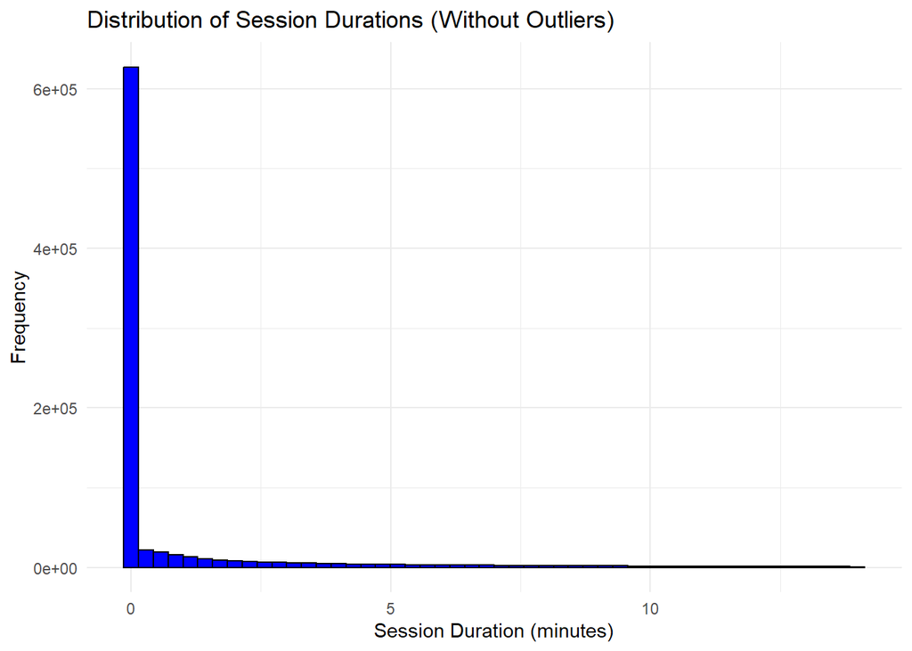

```r
# Calculate the 95th percentile of session durations
cutoff_max <- quantile(session_data$session_duration, 0.90)
cutoff_min <- quantile(session_data$session_duration, 0.10)

# Filter out durations longer than the cutoff
filtered_session_data <- session_data %>%
  filter(session_duration <= cutoff_max) %>%
    filter(session_duration >= cutoff_min)


ggplot(filtered_session_data, aes(x=session_duration)) +
  geom_histogram(bins=50, fill="blue", color="black") +
  labs(title="Distribution of Session Durations (Without Outliers)",
       x="Session Duration (minutes)",
       y="Frequency") +
  theme_minimal()
```

#### Session Duration Analysis

The session duration histogram indicates that the distribution is heavily skewed to the right, with the majority of sessions lasting less than one minute. This suggests that a significant portion of users leave the website shortly after arriving or only stay long enough to view a few items.

**Recommendations:** - **Enhance User Engagement:** Improve the website’s initial engagement by optimizing landing pages, simplifying navigation, and prominently displaying attractive offers or popular products. - **Increase Session Length:** Implement strategies such as personalized content, interactive elements, and incentives for deeper exploration (e.g., discounts or special offers after browsing certain pages).

**Market Basket Analysis**

```r
#transactions <- as(split(dataset$event_type, dataset$product_id), "transactions")

# Generate the item frequency plot for the top 20 items
#itemFrequencyPlot(transactions, topN = 20, type = "absolute", main = "Item Frequency")

# Use the Apriori algorithm to generate association rules
#rules <- apriori(transactions, parameter = list(supp = 0.7, conf = 0.8))

# View the top 5 rules
#inspect(head(rules, n = 5))
```